# Lab 4 - Data Visualization

Author

Arianna Hernandez

# Learning Goals

- Read in and prepare the meteorological dataset
- Create several graphs with different `geoms()` in `ggplot2`
- Create a facet graph
- Conduct some customizations to the graphs
- Create a more detailed map using `leaflet()`

# Lab Description

We will again work with the meteorological data presented in lecture.

**The objective of the lab is to examine the association between weekly average dew point and wind speed in four regions of the US and by elevation.**

Per [Wikipedia](https://en.wikipedia.org/wiki/Dew_point): “The dew point of a given body of air is the temperature to which it must be cooled to become saturated with water vapor. This temperature depends on the pressure and water content of the air.”

Again, feel free to supplement your knowledge of this dataset by checking out the [data dictionary](https://github.com/USCbiostats/data-science-data/blob/master/02_met/met-datadictionary.pdf).

# Steps

### 1. Read in the data

First download and then read in with `data.table::fread()`

```r
if (!file.exists("met_all.gz"))
  download.file(
    url = "https://raw.githubusercontent.com/USCbiostats/data-science-data/master/02_met/met_all.gz",
    destfile = "met_all.gz",
    method   = "libcurl",
    timeout  = 60
    )
met <- data.table::fread("met_all.gz")
```

### 2. Prepare the data

- Remove temperatures less than -17C
- Make sure there are no missing data in the key variables coded as 9999, 999, etc

```r
met[temp <= -17.0, temp := NA]
met[elev == 9999.0, elev := NA]
```

- Generate a date variable using the functions `as.Date()` (hint: You will need the following to create a date `paste(year, month, day, sep = "-")`).

```r
library(lubridate)
library(tidyverse)
met <- met %>%
mutate(date = as.Date(paste(year, month, day, sep = "-")))
```

- Using the `data.table::week` function, keep the observations of the first week of the month.

```r
met <- met %>%
mutate(weeks = data.table::week(date)) %>%
filter(weeks == min(weeks, na.rm =TRUE))
```

- Compute the mean by station of the variables `temp`, `rh`, `wind.sp`, `vis.dist`, `dew.point`, `lat`, `lon`, and `elev`.

```r
met_average <- met[,.(
  temp     = mean(temp,na.rm=TRUE),
  rh       = mean(rh,na.rm=TRUE),
  wind.sp  = mean(wind.sp,na.rm=TRUE),
  dew.point = mean(dew.point,na.rm=TRUE),
  vis.dist = mean(vis.dist,na.rm=TRUE),
  lat      = mean(lat),
  lon      = mean(lon),
  elev     = mean(elev,na.rm=TRUE)
), by=c("USAFID", "day")]
```

- Create a region variable for NW, SW, NE, SE based on lon = -98.00 and lat = 39.71 degrees

```r
met_average <- met_average %>%
mutate(region = if_else(lon >= -98.00 & lat > 39.71, "NE", if_else(
lon <= -98.00 & lat > 39.71, "NW", if_else(
lon >= -98.00 & lat < 39.71, "SW", "SE"
))))
```

- Create a categorical variable for elevation as in the lecture slides

```r
met_average <- met_average %>%
mutate(elev_cat = if_else(elev > 252, "high", "low"))
```

### 3. Use `geom_violin` to examine the wind speed and dew point by region

You saw how to use `geom_boxplot` in class. Try using `geom_violin` instead (take a look at the help). (hint: You will need to set the `x` aesthetic to 1)

- Use facets
- Make sure to deal with `NA`s
- Describe what you observe in the graph

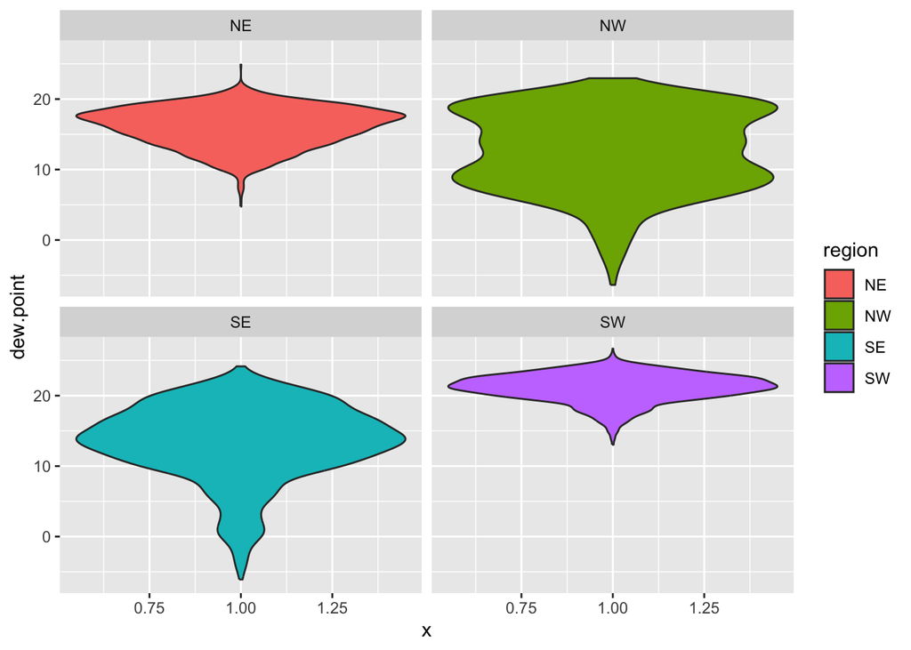

```r
met_average %>%
filter(!is.na(region)) %>%
ggplot() +
geom_violin(mapping = aes(x = 1, y = dew.point, fill = region)) +
facet_wrap(~ region, nrow = 2)
```

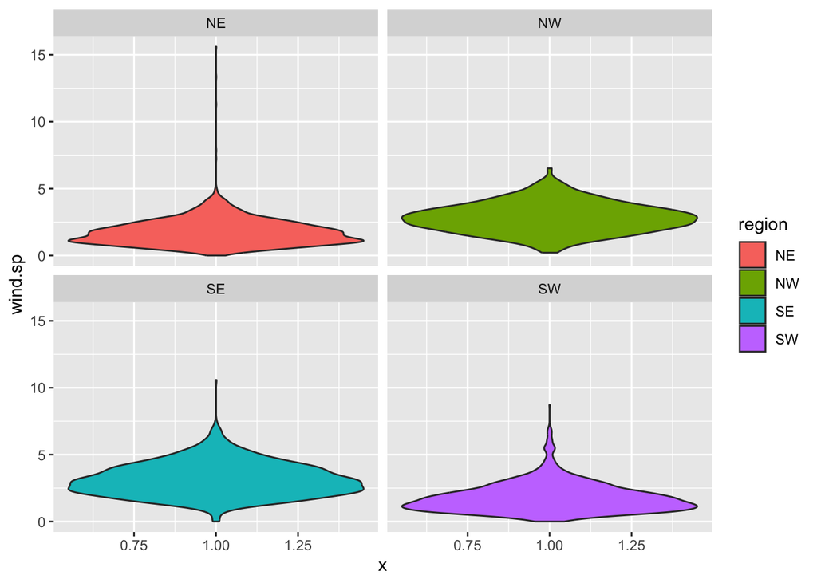

```r
met_average %>%
filter(!is.na(region)) %>%
ggplot() +
geom_violin(mapping = aes(x = 1, y = wind.sp, fill = region)) +
facet_wrap(~ region, nrow = 2)
```

As for dew point, there is no consistency. As oposed to wind speed, the tendency is overall on the higher side for this variable. We can see the Northeast and Southwest have the highest concentrations overall, while the Northwest is all over the place with dew point levels.

### 4. Use `geom_jitter` with `stat_smooth` to examine the association between dew point and wind speed by region

- Color points by region
- Make sure to deal with `NA`s
- Fit a linear regression line by region
- Describe what you observe in the graph

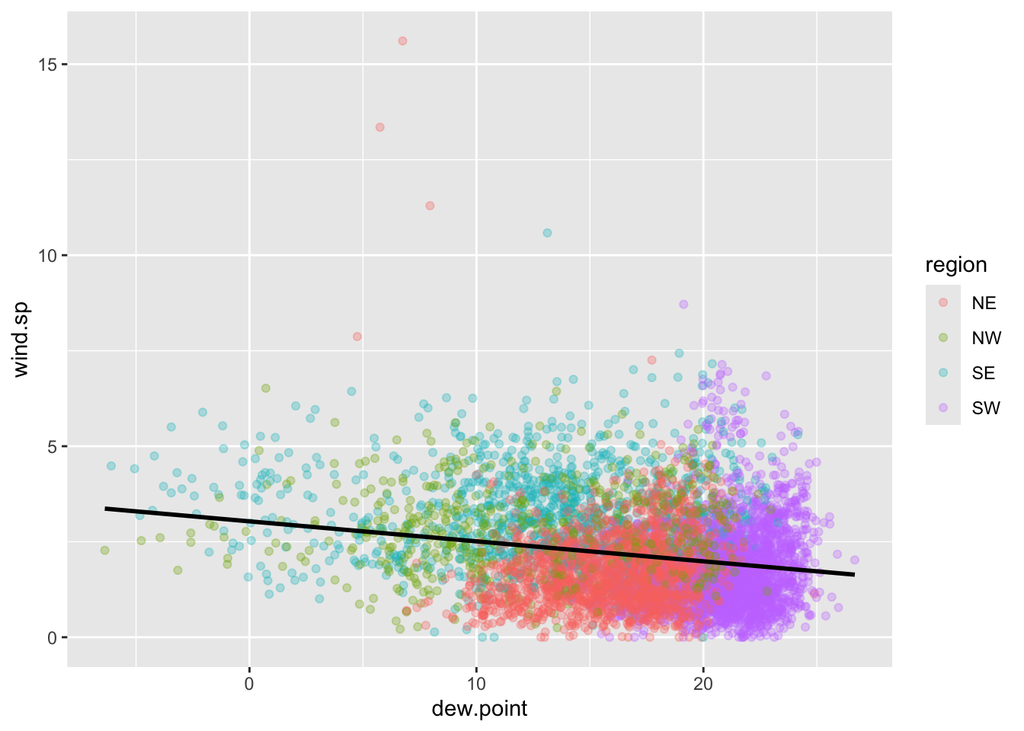

```r
ggplot(data = met_average, mapping = aes(x= dew.point, y= wind.sp, color = region)) +
geom_point(alpha = 0.3, position = "jitter") +
  geom_smooth(method = "lm", se = FALSE, color = "black")
```

The graph shows clustering between the dew points and the wind speed. The regression line shows a slight negative correlation, though there does not seem to be any clear relationship between the four regions’ wind speed and dew points.

### 5. Use `geom_bar` to create barplots of the weather stations by elevation category colored by region

- Bars by elevation category using `position="dodge"`
- Change colors from the default. Color by region using `scale_fill_brewer` see [this](http://rstudio-pubs-static.s3.amazonaws.com/5312_98fc1aba2d5740dd849a5ab797cc2c8d.html)
- Create nice labels on the axes and add a title
- Describe what you observe in the graph
- Make sure to deal with `NA` values

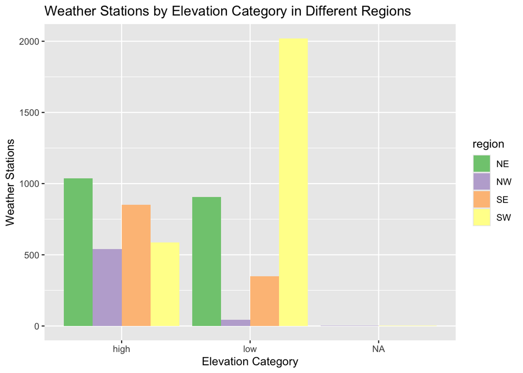

```r
met_average[!is.na(region)] |>
ggplot() +
geom_bar(mapping = aes(x = elev_cat, fill = region), position = "dodge") +
scale_fill_brewer(palette = "Accent") +
labs(x = "Elevation Category", y = "Weather Stations", title = "Weather Stations by Elevation Category in Different Regions")
```

### 6. Use `stat_summary` to examine mean dew point and wind speed by region with standard deviation error bars

- Make sure to remove `NA`s
- Use `fun.data="mean_sdl"` in `stat_summary`
- Add another layer of `stats_summary` but change the geom to `"errorbar"` (see the help).
- Describe the graph and what you observe
- Dew point is…
- Wind speed is…

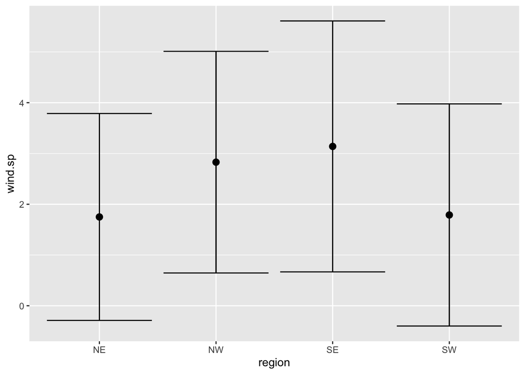

```r
met_average[!is.na(region)] |>
ggplot(mapping = aes(x = region, y = wind.sp)) +
stat_summary(fun.data="mean_sdl", geom = "errorbar") +
stat_summary(fun.data="mean_sdl")
```

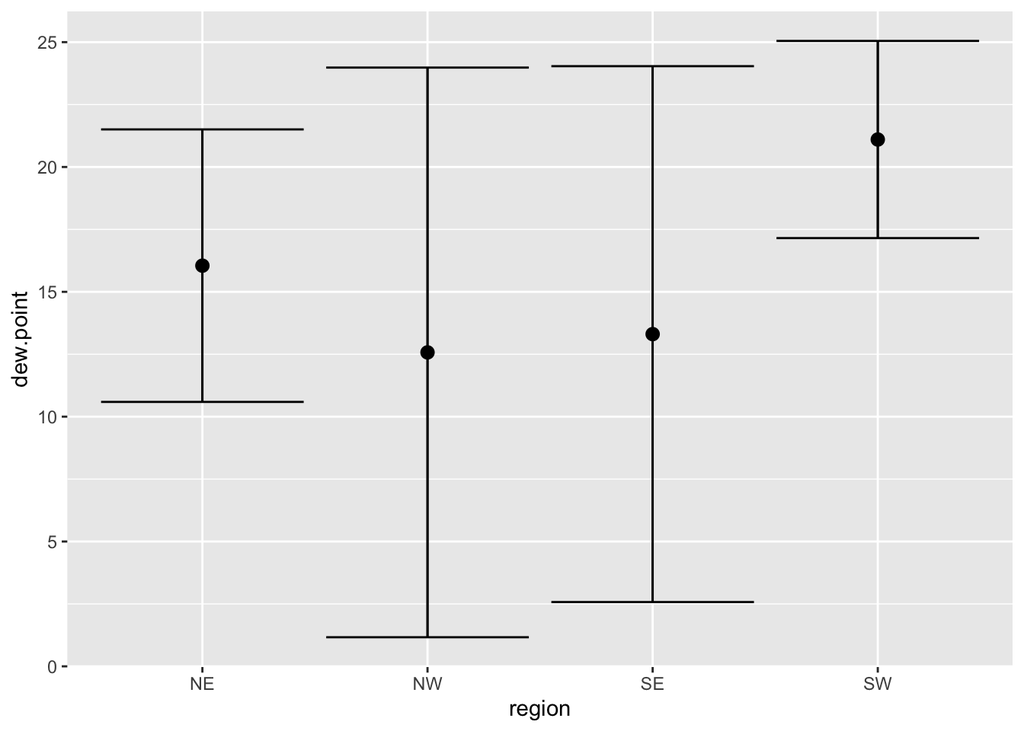

```r
met_average[!is.na(region)] |>
ggplot(mapping = aes(x = region, y = dew.point)) +
stat_summary(fun.data="mean_sdl", geom = "errorbar") +
stat_summary(fun.data="mean_sdl")
```

- Make sure to remove `NA`s
- Use leaflet()
- Make a color palette with custom colors
- Use `addMarkers` to include the top 10 places in relative humidity (hint: this will be useful `rank(-rh) <= 10`)
- Add a legend
- Describe the trend in RH across the US

```r
library(leaflet)

met_avg2 <- met_average[!is.na(rh)]
met_avg2 <- met_avg2[,.(rh = mean(rh), lat = mean(lat), lon = mean(lon)),  by="USAFID"]

rh_pal <- colorNumeric(c('darkred', 'orange', 'yellow3'), domain=met_avg2$rh)

topTen <-met_avg2[rank(-rh) <= 10]

leaflet(met_avg2) |>
 addProviderTiles('Stadia.Outdoors') |>
addCircles(lat = ~lat,
           lng= ~lon,
           label = ~paste0(round(rh,2), 'rh'),
           color = ~ rh_pal(rh),
           opacity = 1,
           fillOpacity = 1,
           radius = 500) |>
addMarkers(lat = ~lat,
           lng= ~lon,
           label = ~paste0(round(rh,2), 'rh'),
                           data = topTen) |>
 addLegend('bottomleft', pal=rh_pal, values=met_avg2$rh,
 title='Relative Humidity', opacity=1)
```

[interactive chart not shown]

Highest humidity trends seem to be in the east of the US, extending to the midwest, where humidity seems to go lower. Highest humidity seems to be in the west of the country and some parts of the south.

### 8. Use a ggplot extension

- Pick an extension (except cowplot) from [here](https://exts.ggplot2.tidyverse.org/gallery/) and make a plot of your choice using the met data (or met_avg)
- Might want to try examples that come with the extension first (e.g. ggtech, gganimate, ggforce)

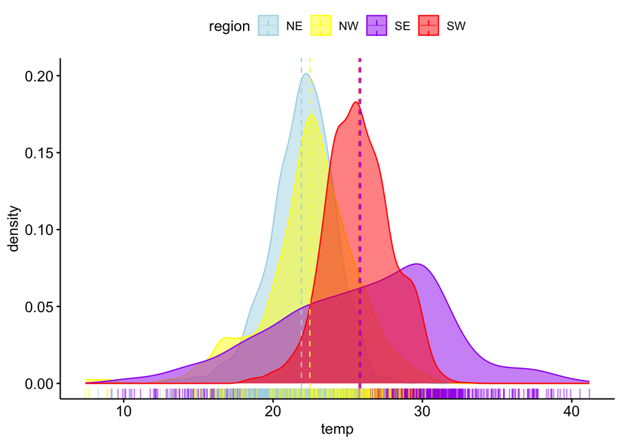

```r
##finding the relationship of temperature by region

library(ggpubr)

set.seed(123)
ggdensity(met_average, x = "temp",
          add = "mean", rug = TRUE,
          color = "region", fill = "region",
          palette = c("lightblue", "yellow", "purple", "red"))
```